# TFM - Clasificación automática de la disfonía mediante parámetros acústicos de la voz

Nicolás López de Aguileta Castaño

2023-01-05

En este documento se describen todos los pasos realizados en el proyecto *Clasificación automática de la disfonía mediante parámetros acústicos de la voz.* Se entrega también el archivo R Markdown correspondiente para garantizar la reproducibilidad.

# Analisis descriptivo de los datos

## Carga de los datos brutos

Los datos utilizados en el presente estudio, están descritos en el primer entregable del proyecto. Los datos se cargan de la tabla de excell `Parametros Analisis Acustico.xlsx`, enviada por el departamento de Otorrinolaringologia de la CUN y revisada por el autor del proyecto. Este fichero se entrego al autor al comienzo de la fase 1 del proyecto.

```r
# Leemos los datos de la carpeta BBDD
rawData<- read_excel("BBDD/Parametros Analisis Acustico.xlsx")

# Comprobamos antes de nada su estructura
str(rawData)
```

```
## tibble [157 x 28] (S3: tbl_df/tbl/data.frame)
##  $ Id      : num [1:157] 1 2 3 4 5 6 7 8 9 10 ...
##  $ Clase   : chr [1:157] "Paralisis" "Paralisis" "Paralisis" "Paralisis" ...
##  $ Fecha   : POSIXct[1:157], format: "2015-10-06" "2016-08-25" ...
##  $ Sexo    : chr [1:157] "M" "M" "M" "M" ...
##  $ Edad    : num [1:157] 69 47 68 65 72 43 41 75 76 62 ...
##  $ FF_A    : num [1:157] 201 237 250 173 154 ...
##  $ Fmax_A  : num [1:157] 257 298 396 216 218 ...
##  $ Fmin_A  : num [1:157] 152 NA NA NA NA ...
##  $ Jitter_A: num [1:157] 0.135 5.041 5.969 1.5 0.764 ...
##  $ Shimer_A: num [1:157] 1.81 9.47 NA 3.05 9.91 ...
##  $ RAR_A   : num [1:157] 16.07 NA NA 13.33 3.87 ...
##  $ CompA_A : num [1:157] -13.27 -13.47 -10.6 -12.51 -9.58 ...
##  $ FF_E    : num [1:157] 216 239 256 257 175 ...
##  $ Fmax_E  : num [1:157] 328 339 NA 196 218 ...
##  $ Fmin_E  : num [1:157] 189 NA NA NA NA ...
##  $ Jitter_E: num [1:157] 0.116 2.633 4.856 0.328 0.898 ...
##  $ Shimer_E: num [1:157] 2.12 5.83 16.8 5.86 4.87 ...
##  $ RAR_E   : num [1:157] 14.51 8.98 6.28 16.65 8.05 ...
##  $ CompA_E : num [1:157] -14.71 -11.62 -10.07 -19.45 -6.11 ...
##  $ FF_I    : num [1:157] 314 245 260 192 205 ...
##  $ Fmax_I  : num [1:157] 270 343 NA 240 286 ...
##  $ Fmin_I  : num [1:157] 185 NA NA NA NA ...
##  $ Jitter_I: num [1:157] 9.47 3.1 6.41 1.68 2.06 ...
##  $ Shimer_I: num [1:157] 4.39 3.16 NA 3.5 6.04 ...
##  $ RAR_I   : num [1:157] 7 9.69 NA 13.75 NA ...
##  $ CompA_I : num [1:157] -6.89 -6.92 -7.84 -11.37 -13.41 ...
##  $ Imax    : num [1:157] 104.2 88.4 95.6 100.3 97.8 ...
##  $ Imin    : num [1:157] 54 55.5 63.6 66.5 66.8 59.5 62.2 59.7 72.4 64.2 ...
```

```r
# Categorizamos las variables Sexo y Clase
rawData$Sexo <- factor(rawData$Sexo, levels = c("V","M") , labels = c("Hombre","Mujer"))
rawData$Clase<-as.factor(rawData$Clase)

#Positivamos los componentes aereos
rawData$CompA_A <- -rawData$CompA_A
rawData$CompA_E <- -rawData$CompA_E
rawData$CompA_I <- -rawData$CompA_I

#Comprobamos la estructura
str(rawData[c("Clase","Sexo")])
```

```
## tibble [157 x 2] (S3: tbl_df/tbl/data.frame)
##  $ Clase: Factor w/ 5 levels "DTM","Neurologicas",..: 5 5 5 5 5 5 5 5 5 5 ...
##  $ Sexo : Factor w/ 2 levels "Hombre","Mujer": 2 2 2 2 2 2 2 2 2 2 ...
```

Por último, eliminaremos las dos primeras variables `Fecha` e `Id`, ya que de momento no existe ningun interés en trabajar con ellas.

```r
rawData <- subset(rawData,select = -c(1,3))
```

## Analsis de los datos faltantes

Se han observado varias muestras con datos faltantes en algunas de las variables, con lo que se procede a cuantificarlas para tomar una decisión al respecto.

Primero comprobamos el número de NA`s por variable. A continuación se muestran las variables con algun dato faltante.

```r
# Sumamos los NAS por variable
nas_all <- apply(is.na(rawData), 2, sum)
#Mostramos las variables con NAS
nas_all[nas_all!=0]
```

```
##   Fmax_A   Fmin_A Shimer_A    RAR_A   Fmax_E   Fmin_E Shimer_E    RAR_E
##        7       29        6       14        8       28        6       14
##   Fmax_I   Fmin_I Shimer_I    RAR_I     Imax     Imin
##        8       28        4       11        2        3
```

```r
# Repetimos lo mismo separando por Clase
nas_class <- by(rawData, rawData$Clase,function(x){apply(is.na(x), 2, sum)})
lapply(nas_class,function(x){x[x!=0]})
```

```
## $DTM
## Fmax_A Fmin_A  RAR_A Fmax_E Fmin_E  RAR_E Fmax_I Fmin_I   Imin
##      1      6      2      1      5      3      1      5      1
##
## $Neurologicas
## Fmax_A Fmin_A Fmax_E Fmin_E  RAR_E Fmax_I Fmin_I  RAR_I   Imax   Imin
##      1      2      1      2      1      1      2      2      2      2
##
## $Normal
## named integer(0)
##
## $Organicas
##   Fmin_A Shimer_A    RAR_A   Fmin_E Shimer_E    RAR_E   Fmin_I    RAR_I
##        5        2        2        5        2        3        5        1
##
## $Paralisis
##   Fmax_A   Fmin_A Shimer_A    RAR_A   Fmax_E   Fmin_E Shimer_E    RAR_E
##        5       16        4       10        6       16        4        7
##   Fmax_I   Fmin_I Shimer_I    RAR_I
##        6       16        4        8
```

Podemos observar cómo es un número de variables bastante elevado el que presenta datos faltantes. En concreto en las frecuencias mínimas de las tres vocales encntramos en torno a un 18.05% de los observaciones incompletas, de las cuales más del 50% pertenecen a la clase `Paralisis`.

```r
# Casos comletos por Clase
by(rawData, rawData$Clase,function(x){nrow(x[complete.cases(x),])})
```

```
## rawData$Clase: DTM
## [1] 11
## ------------------------------------------------------------
## rawData$Clase: Neurologicas
## [1] 13
## ------------------------------------------------------------
## rawData$Clase: Normal
## [1] 35
## ------------------------------------------------------------
## rawData$Clase: Organicas
## [1] 46
## ------------------------------------------------------------
## rawData$Clase: Paralisis
## [1] 9
```

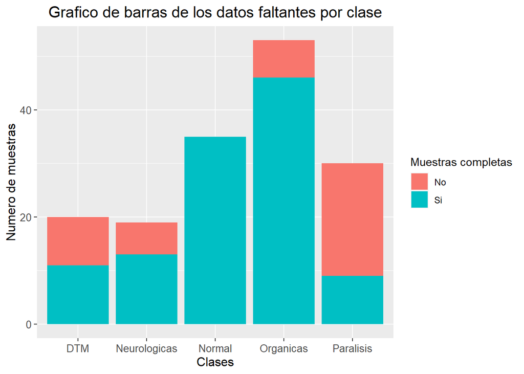

```r
ggplot(data = rawData, aes(x=Clase)) +
  geom_bar(aes(fill = complete.cases(rawData))) +
  xlab("Clases") +
  ylab("Numero de muestras") +
  ggtitle(paste("Grafico de barras de los datos faltantes por clase")) +
  tema +
  scale_fill_discrete(name = "Muestras completas", labels = c("No", "Si"))
```

Al comentarlo con el especialista y el Laboratorio de Voz explican que algunos pacientes no pueden llegar a las frecuencias máximas y mínimas, ya que por su patología no pueden apenas mover la laringe, como es en el caso de la parálisis. Al realizar el estudio,en esos casos no introducian el dato, por lo que es muy interesante poder incluir esta información a la base de datos y no tratarlas como datos faltantes. Tambien existen casos en los que efectivamente no existe el dato ya que en algunos de los estudios anteriores a 2009 no se realizaba el protocolo que se lleva a cabo ahora.

Se propone por lo tanto, imputar el mismo valor de la frecuencia fundamental en los primeros casos ( el paciente no puede realizar voces agudas y/o graves, su voz es muy monótona).

```r
# Imputamos a pacientes sin Fmax y Fmin para cada una de las 3 vocales.
voice <- rawData
vocal_pos<-c(4,11,18)
for (freq in vocal_pos) {
  for (i in 1:nrow(voice)) {
    voice[i,freq+1] <- ifelse(is.na(rawData[i,freq+1]),rawData[i,freq],rawData[i,freq+1])
    voice[i,freq+2] <- ifelse(is.na(rawData[i,freq+2]),rawData[i,freq],rawData[i,freq+2])
  }
}
```

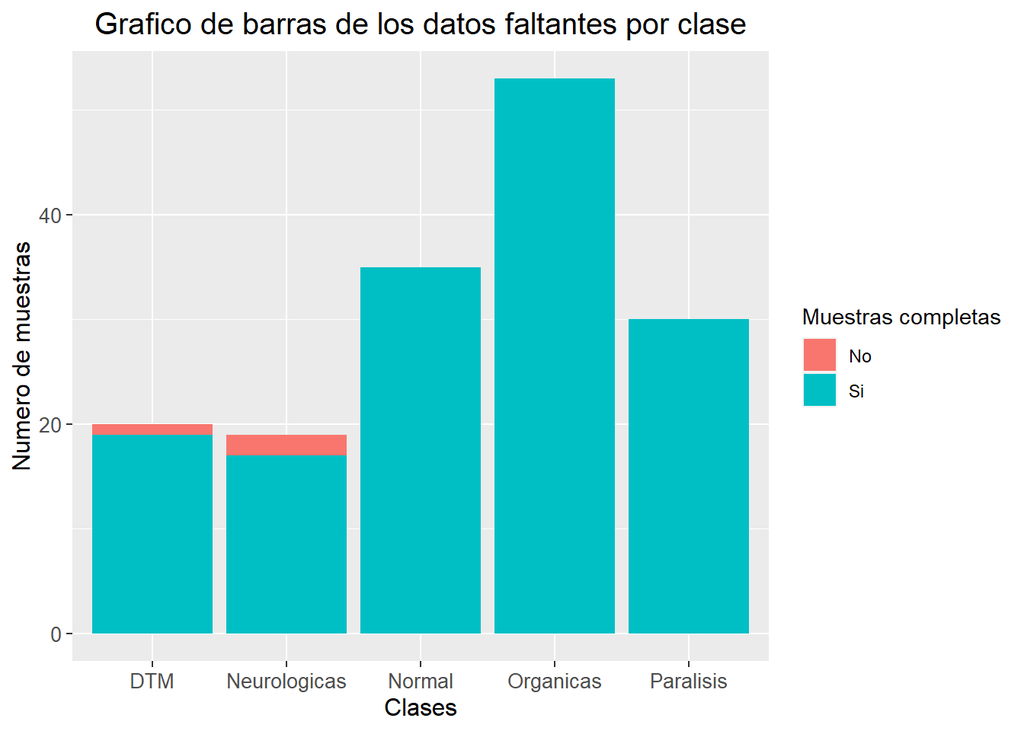

```r
voiceComp <- voice
varNA <- c("Jitter_A", "Shimer_A","Jitter_E", "Shimer_E","Jitter_I", "Shimer_I","RAR_A","RAR_E","RAR_I", "CompA_A","CompA_E","CompA_I")

for (var in varNA) {
    voiceComp[is.na(voiceComp[var]),var] <- max(voice[var], na.rm = T)
}

voice <- voiceComp

ggplot(data = voice, aes(x=Clase)) +
  geom_bar(aes(fill = complete.cases(voice))) +
  xlab("Clases") +
  ylab("Numero de muestras") +
  ggtitle(paste("Grafico de barras de los datos faltantes por clase")) +
  tema +
  scale_fill_discrete(name = "Muestras completas", labels = c("No", "Si"))
```

## Volumen de los datos

A continucaión se muestra el volumen de pacientes pr clase y sexo.

```r
addmargins(table(voice$Clase,voice$Sexo))
```

```
##
##                Hombre Mujer Sum
##   DTM               0    20  20
##   Neurologicas      4    15  19
##   Normal            5    30  35
##   Organicas        10    43  53
##   Paralisis         0    30  30
##   Sum              19   138 157
```

Actualmente tenemos un tamaño de muestras normales respeto a las patológicas desproporcionado, si contamos las sumamos en una misma clase, sin embargo si vamos clase a clase el tamaño es más uniforme.La proporción de hombre y mujeres es desproporcionada en las voces patológicas, por lo que no se han incluido muchas voces masculinas en la recogida de datos de voces normales.

## Creación de nuevas variables

Creamos una nueva variable que refleja cuanto podemos subir y bajar la voz respecto de nuestra frecuencia fundamental.Básicamente queremos ver el rango superior e inferior sobre nuestra frecuencia fundamental.Lo cambiaremos al porcentaje respectu su frecuencia fundamental.

```r
#Para la letra A
voice$Rmax_A<-(voice$Fmax_A-voice$FF_A)/voice$FF_A
voice$Rmin_A<-(voice$FF_A-voice$Fmin_A)/voice$FF_A

#Para la letra E
voice$Rmax_E<-(voice$Fmax_E-voice$FF_E)/voice$FF_E
voice$Rmin_E<-(voice$FF_E-voice$Fmin_E)/voice$FF_E

#Para la letra I
voice$Rmax_I<-(voice$Fmax_I-voice$FF_I)/voice$FF_I
voice$Rmin_I<-(voice$FF_I-voice$Fmin_I)/voice$FF_I
```

## Analisis de las variables

Exportamos los datos:

```r
saveRDS(voice,"voice-app/app/data.rds")
```

Para el analisis se ha creado una pequeña pagina en Shiny llamada [AhotsApp](https://ahotslab.shinyapps.io/AhotsApp/).

Se sacan varias conclusiones tras su exploración. Lá mas importante de todas es que existen errores en la base de datos, ya que al observar la variable Rmax, podemos ver resultados negartivos. Esto deberia de ser imposible, ya que dado que la variable es la resta entre una frecuencia mayor que la otra, todos los resultados deberian de ser positivos. A continuación se muestra el gráfico:

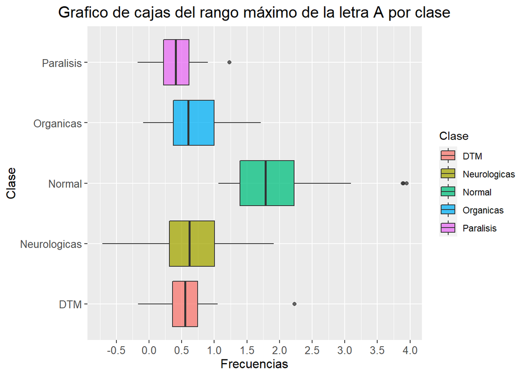

```r
ggplot(data = voice, aes(x=Rmax_A, y=Clase,fill=Clase )) +
      geom_boxplot(alpha = 0.75) +
      xlab("Frecuencias") +
      ggtitle(paste("Grafico de cajas del rango máximo de la letra A por clase")) +
      tema +
      scale_x_continuous(n.breaks = 10)
```

Podemos comprobar también el rango de edades de las clases patológicas:

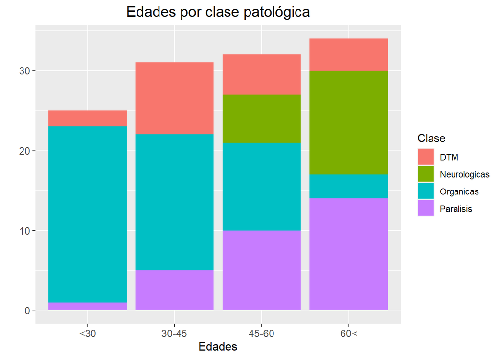

```r
pat <- subset(voice, voice$Clase!="Normal")

ggplot(data = pat, aes(x=as.factor(findInterval(pat$Edad,c(30,45,65))))) +
      geom_bar(aes(fill=Clase)) +
      xlab("Edades") +
      ylab("")+
      ggtitle(paste("Edades por clase patológica")) +
      tema +
      scale_x_discrete(labels=c("0" = "<30", "1" = "30-45",
                              "2" = "45-60","3" = "60<"))
```

## Corrección BBDD

Tras detectar y corregir la base de datos, se vuelven a cargar y procesar todos los datos:

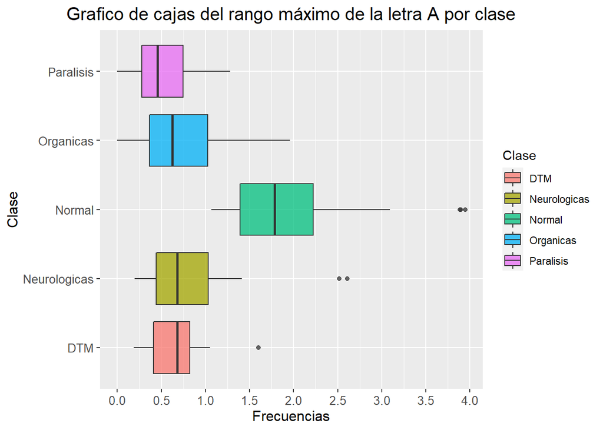

```r
# Leemos los datos de la carpeta BBDD
rawData<- read_excel("BBDD/Parametros Analisis Acustico 03Ene.xlsx")
# Categorizamos las variables Sexo y Clase
rawData$Sexo <- factor(rawData$Sexo, levels = c("V","M") , labels = c("Hombre","Mujer"))
rawData$Clase<-as.factor(rawData$Clase)

#Positivamos los componentes aereos
rawData$CompA_A <- -rawData$CompA_A
rawData$CompA_E <- -rawData$CompA_E
rawData$CompA_I <- -rawData$CompA_I

#Eliminación de variables no utiles
rawData <- subset(rawData,select = -c(1,3))

# Imputamos a pacientes sin Fmax y Fmin para cada una de las 3 vocales.
voice <- rawData
vocal_pos<-c(4,11,18)
for (freq in vocal_pos) {
  for (i in 1:nrow(voice)) {
    voice[i,freq+1] <- ifelse(is.na(rawData[i,freq+1]),rawData[i,freq],rawData[i,freq+1])
    voice[i,freq+2] <- ifelse(is.na(rawData[i,freq+2]),rawData[i,freq],rawData[i,freq+2])
  }
}

# Imputación extra
voiceComp <- voice
varNA <- c("Jitter_A", "Shimer_A","Jitter_E", "Shimer_E","Jitter_I", "Shimer_I","RAR_A","RAR_E","RAR_I", "CompA_A","CompA_E","CompA_I")

for (var in varNA) {
    voiceComp[is.na(voiceComp[var]),var] <- max(voice[var], na.rm = T)
}

voice <- voiceComp

#Creacion de nuevas variables

#Para la letra A
voice$Rmax_A<-(voice$Fmax_A-voice$FF_A)/voice$FF_A
voice$Rmin_A<-(voice$FF_A-voice$Fmin_A)/voice$FF_A

#Para la letra E
voice$Rmax_E<-(voice$Fmax_E-voice$FF_E)/voice$FF_E
voice$Rmin_E<-(voice$FF_E-voice$Fmin_E)/voice$FF_E

#Para la letra I
voice$Rmax_I<-(voice$Fmax_I-voice$FF_I)/voice$FF_I
voice$Rmin_I<-(voice$FF_I-voice$Fmin_I)/voice$FF_I


ggplot(data = voice, aes(x=Rmax_A, y=Clase,fill=Clase )) +
      geom_boxplot(alpha = 0.75) +
      xlab("Frecuencias") +
      ggtitle(paste("Grafico de cajas del rango máximo de la letra A por clase")) +
      tema +
      scale_x_continuous(n.breaks = 10)
```

Eliminamos las variables mal grabadas por la calibracion

```r
#Eliminamos las variables mal grabadas por la calibracion
voice <- voice[-which(voice$Rmax_A<0 | voice$Rmax_E<0 |voice$Rmax_I<0|voice$Rmin_A<0|voice$Rmin_E<0|voice$Rmin_I<0),]
```

Por otro lado, como haremos una primera iteración solo clasificando pacientes sanos de enfermos, Creamos una nueva variable para diferenciarlos.

```r
# Creamos la nueva clase
voice$Clase2 <- voice$Clase
levels(voice$Clase2)<-c("Enfermo","Enfermo","Sano","Enfermo","Enfermo")
```

Finalmente, dividimos en dos bases de datos distintas. En una se utilizan las frecuencias minimas y máximas absolutos y en la otra se utilizan como porcentaje de la frecuencia fundamental. Se elimina tambien la variable `Sexo`.

```r
#Creamos dos nuevas bases de daos
voiceRange <- voice[-c(5,6,12,13,19,20)]
voiceAbs <- voice[-c(27:32)]
```

# Clasificación Sano - Enfermo

En este apartado comenzamos a estudiar la clasificación. Utilizaremos el paquete `caret` para la construcción y validación de los modelos, ya que con pocas lineas de código conseguimos mucho.

Comenzamos estudiando las variables tal y como las obtenemos del análisis acústico.

```r
voiceSelect <- voiceAbs
voiceSelect <- voiceSelect[which(voiceSelect$Sexo=="Mujer"),-1]
```

```r
voice_fase1 <- na.omit(voiceSelect[-1])
colnames(voice_fase1)[25] <- "Clase"
```

Para todos los algoritmos que probemos, utilizaremos el parámetro de control `train control` donde especificaremos el método “*10 times 10 fold crossvalidation*”.

```r
set.seed(123)

folds <- 10
cvIndex <- createFolds(factor(voice_fase1$Clase), folds, returnTrain = T)
ctrl <- trainControl(method = "repeatedcv",
                     classProbs = TRUE,
                     number = 10,
                     repeats = 10,
                     index = cvIndex,
                     summaryFunction = twoClassSummary
                     )
```

### K-Nearest Neighbours

Como vemos en este tipo de algoritmos solo podemos variar la K. Crearemos por lo tanto un vector de distintas k’s para ver que modelo afina mejor. Además, dadas las caractrerísticas del algoritmo, escalaremos y centraremos los datos como preproceso.

```r
set.seed(123)

preProcValues <- preProcess(voice_fase1,method = c("center", "scale"))
normTraining <- predict(preProcValues,voice_fase1)

knn_fase1 <- caret ::train(Clase~.,
           data = normTraining,
           method = "knn",
           metric = "ROC",
           trControl = ctrl,
           tuneGrid = data.frame(k = seq(1,10,by = 1))
           )
knn_fase1
```

```
## k-Nearest Neighbors
##
## 122 samples
##  24 predictor
##   2 classes: 'Enfermo', 'Sano'
##
## No pre-processing
## Resampling: Cross-Validated (10 fold, repeated 10 times)
## Summary of sample sizes: 110, 110, 109, 110, 111, 110, ...
## Resampling results across tuning parameters:
##
##   k   ROC        Sens       Spec
##    1  0.8788889  0.9577778  0.8000000
##    2  0.9570370  0.8955556  0.9000000
##    3  0.9777778  0.9577778  0.8666667
##    4  0.9811111  0.9366667  0.8000000
##    5  0.9811111  0.9477778  0.7666667
##    6  0.9811111  0.9477778  0.9000000
##    7  0.9827778  0.9477778  0.8000000
##    8  0.9844444  0.9477778  0.8333333
##    9  0.9844444  0.9477778  0.8666667
##   10  0.9862963  0.9588889  0.8666667
##
## ROC was used to select the optimal model using the largest value.
## The final value used for the model was k = 10.
```

Corroboramos, que el modelo es muy bueno clasificando los datos.

### Decision Tree

A continuación, ejecutamos el algoritmo de arboles de decision

```r
set.seed(123)

dt_fase1 <-caret:: train(Clase ~ . ,
                     data = voice_fase1,
                     method = "C5.0",
                     metric = "ROC",
                     trControl = ctrl,
                     tuneGrid = expand.grid( .winnow = c(TRUE,FALSE), .trials=c(1,5,10,15,20), .model="tree" )
                    )
dt_fase1
```

```
## C5.0
##
## 122 samples
##  24 predictor
##   2 classes: 'Enfermo', 'Sano'
##
## No pre-processing
## Resampling: Cross-Validated (10 fold, repeated 10 times)
## Summary of sample sizes: 110, 110, 109, 110, 111, 110, ...
## Resampling results across tuning parameters:
##
##   winnow  trials  ROC        Sens       Spec
##   FALSE    1      0.8614815  0.9155556  0.7666667
##   FALSE    5      0.9381481  0.9677778  0.7666667
##   FALSE   10      0.9418519  0.9577778  0.7666667
##   FALSE   15      0.9418519  0.9688889  0.7333333
##   FALSE   20      0.9418519  0.9577778  0.8000000
##    TRUE    1      0.8698148  0.9566667  0.7000000
##    TRUE    5      0.9075926  0.9244444  0.7666667
##    TRUE   10      0.9316667  0.9344444  0.7666667
##    TRUE   15      0.9262963  0.9344444  0.7000000
##    TRUE   20      0.9262963  0.9455556  0.7333333
##
## Tuning parameter 'model' was held constant at a value of tree
## ROC was used to select the optimal model using the largest value.
## The final values used for the model were trials = 10, model = tree and winnow
##  = FALSE.
```

Tambien nos ofrece unos buenos resultados.

### Random forest

A continuación, probaremos con el algoritmo de random forest.

```r
rf_fase1 <-caret:: train(Clase ~ . ,
                     data = voice_fase1,
                     method = "rf",
                     metric = "ROC",
                     trControl = ctrl,
                     tuneGrid = expand.grid(.mtry = c(2,5,10,17,26)))
rf_fase1
```

```
## Random Forest
##
## 122 samples
##  24 predictor
##   2 classes: 'Enfermo', 'Sano'
##
## No pre-processing
## Resampling: Cross-Validated (10 fold, repeated 10 times)
## Summary of sample sizes: 110, 110, 110, 110, 110, 109, ...
## Resampling results across tuning parameters:
##
##   mtry  ROC        Sens       Spec
##    2    0.9762963  0.9888889  0.7833333
##    5    0.9709259  0.9888889  0.8166667
##   10    0.9692593  0.9777778  0.8666667
##   17    0.9742593  0.9677778  0.8666667
##   26    0.9722222  0.9677778  0.8000000
##
## ROC was used to select the optimal model using the largest value.
## The final value used for the model was mtry = 2.
```

### SVM Lineal

Probamos el kernel lineal.Como vemos en este tipo de algoritmos solo podemos variar la C. Crearemos por lo tanto un vector de distintas C’s para ver que modelo afina mejor.

```r
set.seed(123)

svmlin_fase1 <- caret :: train(Clase~.,
           data = voice_fase1,
           method = "svmLinear",
           metric = "ROC",
           trControl = ctrl,
           tuneGrid = expand.grid(C = seq(0.2, 2, by = 0.2))
           )
svmlin_fase1
```

```
## Support Vector Machines with Linear Kernel
##
## 122 samples
##  24 predictor
##   2 classes: 'Enfermo', 'Sano'
##
## No pre-processing
## Resampling: Cross-Validated (10 fold, repeated 10 times)
## Summary of sample sizes: 110, 110, 109, 110, 111, 110, ...
## Resampling results across tuning parameters:
##
##   C    ROC        Sens       Spec
##   0.2  0.9725926  0.9788889  0.7333333
##   0.4  0.9605556  0.9366667  0.7666667
##   0.6  0.9605556  0.9477778  0.7333333
##   0.8  0.9642593  0.9577778  0.7000000
##   1.0  0.9559259  0.9477778  0.7333333
##   1.2  0.9485185  0.9577778  0.7333333
##   1.4  0.9448148  0.9466667  0.7333333
##   1.6  0.9448148  0.9477778  0.7000000
##   1.8  0.9448148  0.9577778  0.7000000
##   2.0  0.9448148  0.9466667  0.6833333
##
## ROC was used to select the optimal model using the largest value.
## The final value used for the model was C = 0.2.
```

### SVM Radial

Probamos el kernel Radial en este caso.

```r
set.seed(123)

svmrad_fase1 <- caret :: train(Clase~.,
           data = voice_fase1,
           method = "svmRadial",
           metric = "ROC",
           trControl = ctrl
           )
svmrad_fase1
```

```
## Support Vector Machines with Radial Basis Function Kernel
##
## 122 samples
##  24 predictor
##   2 classes: 'Enfermo', 'Sano'
##
## No pre-processing
## Resampling: Cross-Validated (10 fold, repeated 10 times)
## Summary of sample sizes: 110, 110, 109, 110, 111, 110, ...
## Resampling results across tuning parameters:
##
##   C     ROC        Sens       Spec
##   0.25  0.9825926  0.9366667  0.9333333
##   0.50  0.9829630  0.9788889  0.8000000
##   1.00  0.9829630  0.9788889  0.8333333
##
## Tuning parameter 'sigma' was held constant at a value of 0.0418038
## ROC was used to select the optimal model using the largest value.
## The final values used for the model were sigma = 0.0418038 and C = 0.5.
```

### Global

Obtenemos un resumen del ROC de los modelos:

```r
Abs_Fase1<-tibble(Model=c('KNN','Decision Tree','Random Forest','SVM Lineal','SVM Radial'),ROC=c(max(knn_fase1$results$ROC),max(dt_fase1$results$ROC),max(rf_fase1$results$ROC),max(svmlin_fase1$results$ROC),max(svmrad_fase1$results$ROC)))
Abs_Fase1 %>% arrange(ROC)
```

[output not shown]

## Variables relativas

```r
set.seed(123)

voice_fase1  <- voiceRange

voice_fase1 <- na.omit(voiceSelect[-1])
colnames(voice_fase1)[25] <- "Clase"

preProcValues <- preProcess(voice_fase1,method = c("center", "scale"))
normTraining <- predict(preProcValues,voice_fase1)

knn_fase1 <- caret ::train(Clase~.,
           data = normTraining,
           method = "knn",
           metric = "ROC",
           trControl = ctrl,
           tuneGrid = data.frame(k = seq(1,10,by = 1))
           )

dt_fase1 <-caret:: train(Clase ~ . ,
                     data = voice_fase1,
                     method = "C5.0",
                     metric = "ROC",
                     trControl = ctrl,
                     tuneGrid = expand.grid( .winnow = c(TRUE,FALSE), .trials=c(1,5,10,15,20), .model="tree" )
                    )

rf_fase1 <-caret:: train(Clase ~ . ,
                     data = voice_fase1,
                     method = "rf",
                     metric = "ROC",
                     trControl = ctrl,
                     tuneGrid = expand.grid(.mtry = c(2,5,10,17,26)))

svmlin_fase1 <- caret :: train(Clase~.,
           data = voice_fase1,
           method = "svmLinear",
           metric = "ROC",
           trControl = ctrl,
           tuneGrid = expand.grid(C = seq(0.2, 2, by = 0.2))
           )

svmrad_fase1 <- caret :: train(Clase~.,
           data = voice_fase1,
           method = "svmRadial",
           metric = "ROC",
           trControl = ctrl
           )

rel_Fase1<-tibble(Model=c('KNN','Decision Tree','Random Forest','SVM Lineal','SVM Radial'),ROC=c(max(knn_fase1$results$ROC),max(dt_fase1$results$ROC),max(rf_fase1$results$ROC),max(svmlin_fase1$results$ROC),max(svmrad_fase1$results$ROC)))
rel_Fase1 %>% arrange(ROC)
```

```
## # A tibble: 5 x 2
##   Model           ROC
##   <chr>         <dbl>
## 1 Decision Tree 0.942
## 2 SVM Lineal    0.973
## 3 Random Forest 0.973
## 4 KNN           0.986
## 5 SVM Radial    0.986
```

# Clasificacion por patologia

## Todas las clases

A continuación trabajaremos en la clasificación multiclase. Comenzaremos con todas las clases disponibles, y seguiremos la misma dinámica que en el caso anterior, añadienddo dos nuevos algoritmos.Utilizaremos solamente las variables originales (absolutas), visto que apenas hay diferencias.

```r
voice_fase2 <- na.omit(voiceAbs[-27])
voice_fase2 <- voice_fase2[which(voice_fase2$Sexo=="Mujer"),-2]
```

Esta vez, crearemos una particion de datos para medir el rendimiento.

```r
set.seed(123)

inTraining <- createDataPartition(voice_fase2$Clase,p=.75,list = FALSE)
training <- voice_fase2[ inTraining,]
testing  <- voice_fase2[-inTraining,]
```

Comprobamos como queda distribuido:

```r
# Testing
table(testing$Clase)
```

```
##
##          DTM Neurologicas       Normal    Organicas    Paralisis
##            4            3            7            9            6
```

```r
# Training
table(training$Clase)
```

```
##
##          DTM Neurologicas       Normal    Organicas    Paralisis
##           12           10           21           29           21
```

Muy probablemente tendremos problemas con algunos algoritmos dada la poca cantidad de muestras en algunas de las clases.A continuación creamos la variable para la validación cruzada.

```r
set.seed(123)

folds <- 10
cvIndex <- createFolds(factor(training$Clase), folds, returnTrain = T)

ctrl <- trainControl(method = "repeatedcv",
                     number = 10,
                     repeats = 10,
                     index = cvIndex,
                     summaryFunction = multiClassSummary
                     )
```

### K-Nearest Neighbours

Probamos con KNN.

```r
set.seed(123)

preProcValues <- preProcess(training,method = c("center", "scale"))
normTraining <- predict(preProcValues,training)

knn_all <- caret ::train(Clase~.,
           data = normTraining,
           method = "knn",
           metric = "Kappa",
           trControl = ctrl,
           tuneGrid = data.frame(k = seq(1,10,by = 1))
           )
knn_all
```

```
## k-Nearest Neighbors
##
## 93 samples
## 24 predictors
##  5 classes: 'DTM', 'Neurologicas', 'Normal', 'Organicas', 'Paralisis'
##
## No pre-processing
## Resampling: Cross-Validated (10 fold, repeated 10 times)
## Summary of sample sizes: 84, 84, 83, 84, 84, 85, ...
## Resampling results across tuning parameters:
##
##   k   Accuracy   Kappa      Mean_F1    Mean_Sensitivity  Mean_Specificity
##    1  0.4883838  0.3412116  0.6600000  0.4466667         0.8691429
##    2  0.4808838  0.3352967        NaN  0.4633333         0.8671349
##    3  0.5644192  0.4269870  0.6600000  0.5066667         0.8847540
##    4  0.5575505  0.4231372  0.7866667  0.5066667         0.8843413
##    5  0.6062121  0.4735333        NaN  0.5066667         0.8939365
##    6  0.6079545  0.4775622        NaN  0.5300000         0.8940952
##    7  0.6506566  0.5318014  0.8704762  0.5733333         0.9050079
##    8  0.6404545  0.5148572  0.7409524  0.5533333         0.9002063
##    9  0.6384343  0.5086662  0.7409524  0.5300000         0.8995079
##   10  0.6273232  0.4948715  0.7409524  0.5200000         0.8972063
##   Mean_Pos_Pred_Value  Mean_Neg_Pred_Value  Mean_Precision  Mean_Recall
##   0.5500000            0.8704026            0.5500000       0.4466667
##   0.4500000            0.8718153            0.4500000       0.4633333
##   0.6333333            0.8926717            0.6333333       0.5066667
##   0.6111111            0.8892439            0.6111111       0.5066667
##   0.5200000            0.9111955            0.5200000       0.5066667
##   0.6000000            0.9080209            0.6000000       0.5300000
##   0.7711111            0.9200368            0.7711111       0.5733333
##   0.6666667            0.9195130            0.6666667       0.5533333
##   0.6766667            0.9203701            0.6766667       0.5300000
##   0.6666667            0.9181479            0.6666667       0.5200000
##   Mean_Detection_Rate  Mean_Balanced_Accuracy
##   0.09767677           0.6579048
##   0.09617677           0.6652341
##   0.11288384           0.6957103
##   0.11151010           0.6955040
##   0.12124242           0.7003016
##   0.12159091           0.7120476
##   0.13013131           0.7391706
##   0.12809091           0.7267698
##   0.12768687           0.7147540
##   0.12546465           0.7086032
##
## Kappa was used to select the optimal model using the largest value.
## The final value used for the model was k = 7.
```

Comprobamos la predicción:

```r
set.seed(123)

normTest <- predict(preProcValues,testing)
p <-predict(knn_all, newdata = normTest)

confusionMatrix(p,testing$Clase)$table
```

```
##               Reference
## Prediction     DTM Neurologicas Normal Organicas Paralisis
##   DTM            0            0      0         3         2
##   Neurologicas   0            1      0         2         0
##   Normal         0            0      7         1         0
##   Organicas      3            1      0         3         2
##   Paralisis      1            1      0         0         2
```

```r
confusionMatrix(p,testing$Clase)$overall[2]
```

```
##     Kappa
## 0.2872504
```

```r
round(ml_test(p,testing$Clase)$balanced.accuracy,3)
```

```
##          DTM Neurologicas       Normal    Organicas    Paralisis
##        0.361        0.595        0.929        0.479        0.590
```

### Decision Tree

Probamos el algoritmo de Decision Tree.

```r
set.seed(123)

dt_all <-caret:: train(Clase ~ . ,
                     data = training,
                     method = "C5.0",
                     metric = "Kappa",
                     trControl = ctrl,
                     tuneGrid = expand.grid( .winnow = c(TRUE,FALSE), .trials=c(1,5,10,15,20), .model="tree" )
                    )
dt_all
```

```
## C5.0
##
## 93 samples
## 24 predictors
##  5 classes: 'DTM', 'Neurologicas', 'Normal', 'Organicas', 'Paralisis'
##
## No pre-processing
## Resampling: Cross-Validated (10 fold, repeated 10 times)
## Summary of sample sizes: 84, 84, 83, 84, 84, 85, ...
## Resampling results across tuning parameters:
##
##   winnow  trials  Accuracy   Kappa      Mean_F1    Mean_Sensitivity
##   FALSE    1      0.5463384  0.4204357  0.7000000  0.5133333
##   FALSE    5      0.5785606  0.4511815        NaN  0.5333333
##   FALSE   10      0.5785606  0.4494439        NaN  0.5266667
##   FALSE   15      0.5685606  0.4385307        NaN  0.5200000
##   FALSE   20      0.5885606  0.4651348  0.7266667  0.5466667
##    TRUE    1      0.4657828  0.3053481        NaN  0.4133333
##    TRUE    5      0.5007071  0.3604316        NaN  0.4733333
##    TRUE   10      0.4884848  0.3423478        NaN  0.4700000
##    TRUE   15      0.5241162  0.3811248        NaN  0.4700000
##    TRUE   20      0.5443182  0.4142825        NaN  0.5000000
##   Mean_Specificity  Mean_Pos_Pred_Value  Mean_Neg_Pred_Value  Mean_Precision
##   0.8857937         0.7288889            0.8930541            0.7288889
##   0.8896032         0.5777778            0.9017763            0.5777778
##   0.8886111         0.3500000            0.8997605            0.3500000
##   0.8863095         0.3750000            0.8980065            0.3750000
##   0.8920238         0.5166667            0.9037525            0.5166667
##   0.8620635         0.4388889            0.8686811            0.4388889
##   0.8726587         0.3777778            0.8844351            0.3777778
##   0.8686349         0.4000000            0.8803167            0.4000000
##   0.8764683         0.4000000            0.8872684            0.4000000
##   0.8836349         0.4000000            0.8963882            0.4000000
##   Mean_Recall  Mean_Detection_Rate  Mean_Balanced_Accuracy
##   0.5133333    0.10926768           0.6995635
##   0.5333333    0.11571212           0.7114683
##   0.5266667    0.11571212           0.7076389
##   0.5200000    0.11371212           0.7031548
##   0.5466667    0.11771212           0.7193452
##   0.4133333    0.09315657           0.6376984
##   0.4733333    0.10014141           0.6729960
##   0.4700000    0.09769697           0.6693175
##   0.4700000    0.10482323           0.6732341
##   0.5000000    0.10886364           0.6918175
##
## Tuning parameter 'model' was held constant at a value of tree
## Kappa was used to select the optimal model using the largest value.
## The final values used for the model were trials = 20, model = tree and winnow
##  = FALSE.
```

Comprobamos la predicción:

```r
set.seed(123)

p <-predict(dt_all, newdata = testing)

confusionMatrix(p,testing$Clase)$table
```

```
##               Reference
## Prediction     DTM Neurologicas Normal Organicas Paralisis
##   DTM            0            1      0         1         0
##   Neurologicas   0            1      0         2         0
##   Normal         0            0      7         0         0
##   Organicas      2            0      0         4         3
##   Paralisis      2            1      0         2         3
```

```r
confusionMatrix(p,testing$Clase)$overall[2]
```

```
##    Kappa
## 0.371517
```

```r
round(ml_test(p,testing$Clase)$balanced.accuracy,3)
```

```
##          DTM Neurologicas       Normal    Organicas    Paralisis
##        0.441        0.604        1.000        0.566        0.603
```

### Random forest

Probamos el algoritmmo de Random Forest.

```r
set.seed(123)

rf_all <-caret:: train(Clase ~ . ,
                     data = training,
                     method = "rf",
                     metric = "Kappa",
                     trControl = ctrl,
                     tuneGrid = expand.grid(.mtry = c(2,5,10,17,26)))
rf_all
```

```
## Random Forest
##
## 93 samples
## 24 predictors
##  5 classes: 'DTM', 'Neurologicas', 'Normal', 'Organicas', 'Paralisis'
##
## No pre-processing
## Resampling: Cross-Validated (10 fold, repeated 10 times)
## Summary of sample sizes: 84, 84, 83, 84, 84, 85, ...
## Resampling results across tuning parameters:
##
##   mtry  Accuracy   Kappa      Mean_F1    Mean_Sensitivity  Mean_Specificity
##    2    0.6890404  0.5812768        NaN  0.5933333         0.9137698
##    5    0.7041919  0.6030347  1.0000000  0.6166667         0.9187937
##   10    0.7132828  0.6172573  1.0000000  0.6333333         0.9221825
##   17    0.6783586  0.5736008  0.7716667  0.6100000         0.9137540
##   26    0.6459343  0.5325584  0.8150000  0.5866667         0.9062778
##   Mean_Pos_Pred_Value  Mean_Neg_Pred_Value  Mean_Precision  Mean_Recall
##         NaN            0.9314747                  NaN       0.5933333
##   1.0000000            0.9343009            1.0000000       0.6166667
##   0.8500000            0.9351573            0.8500000       0.6333333
##   0.8433333            0.9255628            0.8433333       0.6100000
##   0.8355556            0.9175945            0.8355556       0.5866667
##   Mean_Detection_Rate  Mean_Balanced_Accuracy
##   0.1378081            0.7535516
##   0.1408384            0.7677302
##   0.1426566            0.7777579
##   0.1356717            0.7618770
##   0.1291869            0.7464722
##
## Kappa was used to select the optimal model using the largest value.
## The final value used for the model was mtry = 10.
```

Comprobamos la predicción:

```r
set.seed(123)

p <-predict(rf_all, newdata = testing)
confusionMatrix(p,testing$Clase)$table
```

```
##               Reference
## Prediction     DTM Neurologicas Normal Organicas Paralisis
##   DTM            0            0      0         1         0
##   Neurologicas   0            2      0         2         0
##   Normal         0            0      7         1         0
##   Organicas      3            0      0         4         3
##   Paralisis      1            1      0         1         3
```

```r
confusionMatrix(p,testing$Clase)$overall[2]
```

```
##     Kappa
## 0.4136858
```

```r
round(ml_test(p,testing$Clase)$balanced.accuracy,3)
```

```
##          DTM Neurologicas       Normal    Organicas    Paralisis
##        0.471        0.771        0.950        0.556        0.656
```

### SVM Lineal

Probamos SVM con el kernel lineal.

```r
set.seed(123)

svmlin_all <- caret :: train(Clase~.,
           data = training,
           method = "svmLinear",
           metric = "Kappa",
           trControl = ctrl,
           tuneGrid = expand.grid(C = seq(0.2, 2, by = 0.2))
           )
svmlin_all
```

```
## Support Vector Machines with Linear Kernel
##
## 93 samples
## 24 predictors
##  5 classes: 'DTM', 'Neurologicas', 'Normal', 'Organicas', 'Paralisis'
##
## No pre-processing
## Resampling: Cross-Validated (10 fold, repeated 10 times)
## Summary of sample sizes: 84, 84, 83, 84, 84, 85, ...
## Resampling results across tuning parameters:
##
##   C    Accuracy   Kappa      Mean_F1    Mean_Sensitivity  Mean_Specificity
##   0.2  0.6570455  0.5560468  0.6866667  0.6100000         0.9138016
##   0.4  0.6572475  0.5564984  0.6866667  0.6033333         0.9142540
##   0.6  0.6114141  0.5005186  0.6866667  0.5700000         0.9034206
##   0.8  0.6259343  0.5186756  0.6866667  0.5800000         0.9072540
##   1.0  0.6148232  0.5029379  0.6866667  0.5700000         0.9039206
##   1.2  0.6148232  0.5043830  0.7900000  0.5833333         0.9043968
##   1.4  0.6057323  0.4926809  0.7900000  0.5766667         0.9018968
##   1.6  0.6057323  0.4926809  0.7900000  0.5766667         0.9018968
##   1.8  0.5946212  0.4812055  0.7900000  0.5700000         0.8993968
##   2.0  0.5946212  0.4812055  0.7900000  0.5700000         0.8993968
##   Mean_Pos_Pred_Value  Mean_Neg_Pred_Value  Mean_Precision  Mean_Recall
##   0.6547619            0.9170635            0.6547619       0.6100000
##   0.7366667            0.9188723            0.7366667       0.6033333
##   0.6750000            0.9069278            0.6750000       0.5700000
##   0.6666667            0.9103175            0.6666667       0.5800000
##   0.6666667            0.9078175            0.6666667       0.5700000
##   0.6904762            0.9073175            0.6904762       0.5833333
##   0.6833333            0.9044603            0.6833333       0.5766667
##   0.6833333            0.9044603            0.6833333       0.5766667
##   0.6833333            0.9021825            0.6833333       0.5700000
##   0.6833333            0.9021825            0.6833333       0.5700000
##   Mean_Detection_Rate  Mean_Balanced_Accuracy
##   0.1314091            0.7619008
##   0.1314495            0.7587937
##   0.1222828            0.7367103
##   0.1251869            0.7436270
##   0.1229646            0.7369603
##   0.1229646            0.7438651
##   0.1211465            0.7392817
##   0.1211465            0.7392817
##   0.1189242            0.7346984
##   0.1189242            0.7346984
##
## Kappa was used to select the optimal model using the largest value.
## The final value used for the model was C = 0.4.
```

Comprobamos la predicción:

```r
set.seed(123)

p <-predict(svmlin_all, newdata = testing)
confusionMatrix(p,testing$Clase)$table
```

```
##               Reference
## Prediction     DTM Neurologicas Normal Organicas Paralisis
##   DTM            0            0      0         0         1
##   Neurologicas   1            2      1         2         1
##   Normal         0            1      6         0         0
##   Organicas      1            0      0         5         1
##   Paralisis      2            0      0         2         3
```

```r
confusionMatrix(p,testing$Clase)$overall[2]
```

```
##     Kappa
## 0.4305136
```

```r
round(ml_test(p,testing$Clase)$balanced.accuracy,3)
```

```
##          DTM Neurologicas       Normal    Organicas    Paralisis
##        0.471        0.702        0.883        0.701        0.632
```

### SVM Radial

Probamos ahora con el kernel Radial.

```r
set.seed(123)

svmrad_all <- caret :: train(Clase~.,
           data = training,
           method = "svmRadial",
           metric = "Kappa",
           trControl = ctrl
           )
svmrad_all
```

```
## Support Vector Machines with Radial Basis Function Kernel
##
## 93 samples
## 24 predictors
##  5 classes: 'DTM', 'Neurologicas', 'Normal', 'Organicas', 'Paralisis'
##
## No pre-processing
## Resampling: Cross-Validated (10 fold, repeated 10 times)
## Summary of sample sizes: 84, 84, 83, 84, 84, 85, ...
## Resampling results across tuning parameters:
##
##   C     Accuracy   Kappa      Mean_F1  Mean_Sensitivity  Mean_Specificity
##   0.25  0.6255051  0.4765985  NaN      0.4766667         0.8923810
##   0.50  0.6679293  0.5422068  NaN      0.5266667         0.9057143
##   1.00  0.6910606  0.5794485  NaN      0.5666667         0.9135556
##   Mean_Pos_Pred_Value  Mean_Neg_Pred_Value  Mean_Precision  Mean_Recall
##   NaN                  0.9184509            NaN             0.4766667
##   NaN                  0.9271176            NaN             0.5266667
##   NaN                  0.9334596            NaN             0.5666667
##   Mean_Detection_Rate  Mean_Balanced_Accuracy
##   0.1251010            0.6845238
##   0.1335859            0.7161905
##   0.1382121            0.7401111
##
## Tuning parameter 'sigma' was held constant at a value of 0.03081311
## Kappa was used to select the optimal model using the largest value.
## The final values used for the model were sigma = 0.03081311 and C = 1.
```

Comprobamos la predicción:

```r
set.seed(123)

p <-predict(svmrad_all, newdata = testing)
confusionMatrix(p,testing$Clase)$table
```

```
##               Reference
## Prediction     DTM Neurologicas Normal Organicas Paralisis
##   DTM            0            0      0         0         0
##   Neurologicas   0            1      0         2         1
##   Normal         0            0      7         0         0
##   Organicas      2            0      0         6         2
##   Paralisis      2            2      0         1         3
```

```r
confusionMatrix(p,testing$Clase)$overall[2]
```

```
##     Kappa
## 0.4579439
```

```r
round(ml_test(p,testing$Clase)$balanced.accuracy,3)
```

```
##          DTM Neurologicas       Normal    Organicas    Paralisis
##        0.500        0.588        1.000        0.700        0.618
```

### XGBoost

A continución probamos con el algoritmo XGBoost.

```r
set.seed(123)

dat <- voice_fase2
dat$Clase <- as.numeric(dat$Clase)
dat$Clase <- dat$Clase - 1

# Full data set
data_variables <- as.matrix(dat[,-1])
data_label <- as.matrix( dat[,"Clase"])
data_matrix <- xgb.DMatrix(data = as.matrix(dat), label = data_label)
# split train data and make xgb.DMatrix
train_data   <- data_variables[inTraining,]
train_label  <- data_label[inTraining,]
train_matrix <- xgb.DMatrix(data = train_data, label = train_label)
# split test data and make xgb.DMatrix
test_data  <- data_variables[-inTraining,]
test_label <- data_label[-inTraining]
test_matrix <- xgb.DMatrix(data = test_data, label = test_label)

xgboost_all <- xgboost:: xgboost(data = train_matrix,
 eta = 0.1,
 max_depth = 15,
 nround=30,
 subsample = 0.5,
 colsample_bytree = 0.5,
 eval_metric = "mlogloss",
 objective = "multi:softprob",
 num_class = 5,
 nthread = 3,
 verbose = F
)
```

Comprobamos la predicción:

```r
set.seed(123)

xgb_preds <- predict(xgboost_all, test_matrix, reshape = TRUE)
xgb_preds <- as.data.frame(xgb_preds)
colnames(xgb_preds) <- levels(voice_fase2$Clase)

xgb_preds$PredictedClass <- apply(xgb_preds, 1, function(y) colnames(xgb_preds)[which.max(y)])

xgb_preds$ActualClass <- levels(voice_fase2$Clase)[test_label + 1]

confusionMatrix(factor(xgb_preds$PredictedClass, levels = levels(testing$Clase)),factor(xgb_preds$ActualClass))$table
```

```
##               Reference
## Prediction     DTM Neurologicas Normal Organicas Paralisis
##   DTM            0            0      0         1         0
##   Neurologicas   0            1      0         2         0
##   Normal         0            0      7         0         0
##   Organicas      3            0      0         5         3
##   Paralisis      1            2      0         1         3
```

```r
confusionMatrix(factor(xgb_preds$PredictedClass, levels = levels(testing$Clase)),factor(xgb_preds$ActualClass))$overall[2]
```

```
##     Kappa
## 0.4090909
```

```r
round(ml_test(factor(xgb_preds$PredictedClass, levels = levels(testing$Clase)),factor(xgb_preds$ActualClass))$balanced.accuracy,3)
```

```
##          DTM Neurologicas       Normal    Organicas    Paralisis
##        0.471        0.608        1.000        0.601        0.632
```

### Keras

A continución probamos con las redes neuronales artificiales.

```r
set.seed(123)

train.x <- keras::normalize(as.matrix(training[, -1]))
```

```
## Loaded Tensorflow version 2.8.4
```

```r
train.y <- to_categorical(as.matrix(as.numeric(unlist(training[1]))-1))

test.x <- keras::normalize(as.matrix(testing[, -1]))
test.y <- to_categorical(as.matrix(as.numeric(unlist(testing[1]))-1))

ann_all <- keras_model_sequential() %>%
  layer_dense(units=60, activation = "relu", input_shape = c(24)) %>%
  layer_dense(units=30, activation = "relu") %>%
  layer_dense(units =5, activation = "softmax")

ann_all %>% compile(optimizer = "adam",
                  loss = "categorical_crossentropy",
                  metric=c("accuracy"),
                  )

ann_all %>% keras:: fit(train.x,
              train.y,
              epochs = 300,
              batch_size = 20,
              validation_data = list(test.x, test.y),
              view_metrics = FALSE
              )
```

Comprobamos la predicción:

```r
set.seed(123)

pred <-predict(ann_all,test.x)
pred <- format(round(pred, 2), nsamll = 5)

result <- data.frame("DTM"=pred[,1],
                     "Neurologicas"=pred[,2],
                     "Normal"=pred[,3],
                     "Organicas"=pred[,4],
                     "Paralisis"=pred[,5],
                     "Predicted" = ifelse(max.col(pred[ ,1:5])==1, "DTM",
                                          ifelse(max.col(pred[ ,1:5])==2,"Neurologicas",
                                                 ifelse(max.col(pred[ ,1:5])==3,"Normal" ,
                                                        ifelse(max.col(pred[ ,1:5])==4,"Organicas",
                                                                    "Paralisis")))), Original = testing$Clase)

confusionMatrix(factor(result$Predicted, levels = levels(result$Original)), result$Original)$table
```

```
##               Reference
## Prediction     DTM Neurologicas Normal Organicas Paralisis
##   DTM            0            0      0         0         0
##   Neurologicas   0            0      0         0         1
##   Normal         0            0      7         0         0
##   Organicas      3            0      0         5         1
##   Paralisis      1            3      0         4         4
```

```r
confusionMatrix(factor(result$Predicted, levels = levels(result$Original)), result$Original)$overall[2]
```

```
##     Kappa
## 0.4072327
```

```r
round(ml_test(factor(result$Predicted, levels = levels(result$Original)), result$Original)$balanced.accuracy,3)
```

```
##          DTM Neurologicas       Normal    Organicas    Paralisis
##        0.500        0.471        1.000        0.644        0.633
```

## Eliminando la variable DTM

```r
no_DTM <- subset(voice_fase2,voice_fase2$Clase!="DTM")
no_DTM$Clase<- factor(no_DTM$Clase,levels = c("Normal","Paralisis","Organicas","Neurologicas"))
```

```r
voice_fase2 <- no_DTM
```

```r
set.seed(123)

inTraining <- createDataPartition(voice_fase2$Clase,p=.75,list = FALSE)
training <- voice_fase2[ inTraining,]
testing  <- voice_fase2[-inTraining,]
```

```r
set.seed(123)

folds <- 10
cvIndex <- createFolds(factor(training$Clase), folds, returnTrain = T)

ctrl <- trainControl(method = "repeatedcv",
                     number = 10,
                     repeats = 10,
                     index = cvIndex,
                     summaryFunction = multiClassSummary
)
```

### K-Nearest Neighbours

Probamos con KNN.

```r
set.seed(123)

preProcValues <- preProcess(training,method = c("center", "scale"))
normTraining <- predict(preProcValues,training)

knn_No_DTM <- caret ::train(Clase~.,
           data = normTraining,
           method = "knn",
           metric = "Kappa",
           trControl = ctrl,
           tuneGrid = data.frame(k = seq(1,10,by = 1))
           )
knn_No_DTM
```

```
## k-Nearest Neighbors
##
## 81 samples
## 24 predictors
##  4 classes: 'Normal', 'Paralisis', 'Organicas', 'Neurologicas'
##
## No pre-processing
## Resampling: Cross-Validated (10 fold, repeated 10 times)
## Summary of sample sizes: 73, 73, 73, 73, 73, 73, ...
## Resampling results across tuning parameters:
##
##   k   Accuracy   Kappa      Mean_F1    Mean_Sensitivity  Mean_Specificity
##    1  0.6638889  0.5348976  0.7250000  0.6416667         0.8848512
##    2  0.6916667  0.5860446  0.8079365  0.7166667         0.8977083
##    3  0.7013889  0.5909209  0.8028571  0.6875000         0.8990179
##    4  0.6638889  0.5299053  0.8714286  0.6375000         0.8825893
##    5  0.6763889  0.5516437  0.8461310  0.6500000         0.8879762
##    6  0.7013889  0.5796008  0.8581845  0.6666667         0.8940476
##    7  0.6513889  0.5138051  0.8809524  0.6083333         0.8785714
##    8  0.6763889  0.5423890  0.8857143  0.6458333         0.8840476
##    9  0.6888889  0.5648596  0.8857143  0.6583333         0.8904762
##   10  0.7013889  0.5784238  0.8857143  0.6625000         0.8938095
##   Mean_Pos_Pred_Value  Mean_Neg_Pred_Value  Mean_Precision  Mean_Recall
##   0.7604167            0.8919345            0.7604167       0.6416667
##   0.7886905            0.9066369            0.7886905       0.7166667
##   0.7534722            0.9101488            0.7534722       0.6875000
##   0.8072917            0.8979464            0.8072917       0.6375000
##   0.8000000            0.8984226            0.8000000       0.6500000
##   0.8583333            0.9121131            0.8583333       0.6666667
##   0.8281250            0.8942560            0.8281250       0.6083333
##   0.8333333            0.8990179            0.8333333       0.6458333
##   0.8027778            0.9039286            0.8027778       0.6583333
##   0.8298611            0.9122619            0.8298611       0.6625000
##   Mean_Detection_Rate  Mean_Balanced_Accuracy
##   0.1659722            0.7632589
##   0.1729167            0.8071875
##   0.1753472            0.7932589
##   0.1659722            0.7600446
##   0.1690972            0.7689881
##   0.1753472            0.7803571
##   0.1628472            0.7434524
##   0.1690972            0.7649405
##   0.1722222            0.7744048
##   0.1753472            0.7781548
##
## Kappa was used to select the optimal model using the largest value.
## The final value used for the model was k = 3.
```

Comprobamos la predicción:

```r
set.seed(123)

normTest <- predict(preProcValues,testing)

p <-predict(knn_No_DTM, newdata = normTest)
confusionMatrix(p,testing$Clase)$table
```

```
##               Reference
## Prediction     Normal Paralisis Organicas Neurologicas
##   Normal            7         0         0            0
##   Paralisis         0         4         2            0
##   Organicas         0         1         5            1
##   Neurologicas      0         1         2            2
```

```r
confusionMatrix(p,testing$Clase)$overall[2]
```

```
##     Kappa
## 0.6212121
```

```r
round(ml_test(p,testing$Clase)$balanced.accuracy,3)
```

```
##       Normal    Paralisis    Organicas Neurologicas
##        1.000        0.771        0.711        0.754
```

### Decision Tree

Probamos el algoritmo de Decision Tree.

```r
set.seed(123)

dt_No_DTM <-caret:: train(Clase ~ . ,
                     data = training,
                     method = "C5.0",
                     metric = "Kappa",
                     trControl = ctrl,
                     tuneGrid = expand.grid( .winnow = c(TRUE,FALSE), .trials=c(1,5,10,15,20), .model="tree" )
                    )
dt_No_DTM
```

```
## C5.0
##
## 81 samples
## 24 predictors
##  4 classes: 'Normal', 'Paralisis', 'Organicas', 'Neurologicas'
##
## No pre-processing
## Resampling: Cross-Validated (10 fold, repeated 10 times)
## Summary of sample sizes: 73, 73, 73, 73, 73, 73, ...
## Resampling results across tuning parameters:
##
##   winnow  trials  Accuracy   Kappa      Mean_F1    Mean_Sensitivity
##   FALSE    1      0.6277778  0.4815383  0.7378571  0.6208333
##   FALSE    5      0.6027778  0.4477987  0.7794643  0.6000000
##   FALSE   10      0.6388889  0.5065085  0.7994048  0.6291667
##   FALSE   15      0.6763889  0.5610838  0.7996032  0.7083333
##   FALSE   20      0.6513889  0.5208258  0.7848214  0.6541667
##    TRUE    1      0.5527778  0.3827569  0.7755952  0.5291667
##    TRUE    5      0.5513889  0.3776445  0.7916667  0.5208333
##    TRUE   10      0.5263889  0.3536589  0.7638889  0.5208333
##    TRUE   15      0.5388889  0.3665918  0.7638889  0.5125000
##    TRUE   20      0.5513889  0.3791785  0.7638889  0.5208333
##   Mean_Specificity  Mean_Pos_Pred_Value  Mean_Neg_Pred_Value  Mean_Precision
##   0.8692857         0.7604167            0.8769048            0.7604167
##   0.8607143         0.6339286            0.8719345            0.6339286
##   0.8763095         0.6250000            0.8841369            0.6250000
##   0.8890476         0.7265625            0.8952381            0.7265625
##   0.8782143         0.6536458            0.8845536            0.6536458
##   0.8454464         0.5763889            0.8543254            0.5763889
##   0.8440179         0.5138889            0.8523512            0.5138889
##   0.8379464         0.5590278            0.8489881            0.5590278
##   0.8423512         0.4821429            0.8504167            0.4821429
##   0.8459226         0.5277778            0.8561012            0.5277778
##   Mean_Recall  Mean_Detection_Rate  Mean_Balanced_Accuracy
##   0.6208333    0.1569444            0.7450595
##   0.6000000    0.1506944            0.7303571
##   0.6291667    0.1597222            0.7527381
##   0.7083333    0.1690972            0.7986905
##   0.6541667    0.1628472            0.7661905
##   0.5291667    0.1381944            0.6873065
##   0.5208333    0.1378472            0.6824256
##   0.5208333    0.1315972            0.6793899
##   0.5125000    0.1347222            0.6774256
##   0.5208333    0.1378472            0.6833780
##
## Tuning parameter 'model' was held constant at a value of tree
## Kappa was used to select the optimal model using the largest value.
## The final values used for the model were trials = 15, model = tree and winnow
##  = FALSE.
```

Comprobamos la predicción:

```r
set.seed(123)

p <-predict(dt_No_DTM, newdata = testing)
confusionMatrix(p,testing$Clase)$table
```

```
##               Reference
## Prediction     Normal Paralisis Organicas Neurologicas
##   Normal            6         0         0            1
##   Paralisis         0         6         3            1
##   Organicas         0         0         3            1
##   Neurologicas      1         0         3            0
```

```r
confusionMatrix(p,testing$Clase)$overall[2]
```

```
##    Kappa
## 0.465812
```

```r
round(ml_test(p,testing$Clase)$balanced.accuracy,3)
```

```
##       Normal    Paralisis    Organicas Neurologicas
##        0.879        0.846        0.628        0.395
```

### Random forest

Probamos el algoritmmo de Random Forest.

```r
set.seed(123)

rf_No_DTM <-caret:: train(Clase ~ . ,
                     data = training,
                     method = "rf",
                     metric = "Kappa",
                     trControl = ctrl,
                     tuneGrid = expand.grid(.mtry = c(2,5,10,17,26)))
rf_No_DTM
```

```
## Random Forest
##
## 81 samples
## 24 predictors
##  4 classes: 'Normal', 'Paralisis', 'Organicas', 'Neurologicas'
##
## No pre-processing
## Resampling: Cross-Validated (10 fold, repeated 10 times)
## Summary of sample sizes: 73, 73, 73, 73, 73, 73, ...
## Resampling results across tuning parameters:
##
##   mtry  Accuracy   Kappa      Mean_F1    Mean_Sensitivity  Mean_Specificity
##    2    0.8125000  0.7324174  0.8632143  0.7625000         0.9305952
##    5    0.7638889  0.6649132  0.8198810  0.7208333         0.9139286
##   10    0.7138889  0.5909738  0.8215476  0.6875000         0.8945238
##   17    0.6888889  0.5592359  0.8280952  0.6625000         0.8873810
##   26    0.7013889  0.5786979  0.8307143  0.6750000         0.8940476
##   Mean_Pos_Pred_Value  Mean_Neg_Pred_Value  Mean_Precision  Mean_Recall
##   0.8722222            0.9435119            0.8722222       0.7625000
##   0.8131944            0.9243750            0.8131944       0.7208333
##   0.7489583            0.9002679            0.7489583       0.6875000
##   0.7738095            0.8937202            0.7738095       0.6625000
##   0.7738095            0.8999702            0.7738095       0.6750000
##   Mean_Detection_Rate  Mean_Balanced_Accuracy
##   0.2031250            0.8465476
##   0.1909722            0.8173810
##   0.1784722            0.7910119
##   0.1722222            0.7749405
##   0.1753472            0.7845238
##
## Kappa was used to select the optimal model using the largest value.
## The final value used for the model was mtry = 2.
```

Comprobamos la predicción:

```r
set.seed(123)

p <-predict(rf_No_DTM, newdata = testing)
confusionMatrix(p,testing$Clase)$table
```

```
##               Reference
## Prediction     Normal Paralisis Organicas Neurologicas
##   Normal            5         0         0            0
##   Paralisis         0         5         2            0
##   Organicas         2         1         6            0
##   Neurologicas      0         0         1            3
```

```r
confusionMatrix(p,testing$Clase)$overall[2]
```

```
##     Kappa
## 0.6703297
```

```r
round(ml_test(p,testing$Clase)$balanced.accuracy,3)
```

```
##       Normal    Paralisis    Organicas Neurologicas
##        0.857        0.854        0.740        0.971
```

### SVM Lineal

Probamos SVM con el kernel lineal.

```r
set.seed(123)

svmlin_No_DTM <- caret :: train(Clase~.,
                               data = training,
                               method = "svmLinear",
                               metric = "Kappa",
                               trControl = ctrl,
                               tuneGrid = expand.grid(C = seq(0.2, 2, by = 0.2))
)
svmlin_No_DTM
```

```
## Support Vector Machines with Linear Kernel
##
## 81 samples
## 24 predictors
##  4 classes: 'Normal', 'Paralisis', 'Organicas', 'Neurologicas'
##
## No pre-processing
## Resampling: Cross-Validated (10 fold, repeated 10 times)
## Summary of sample sizes: 73, 73, 73, 73, 73, 73, ...
## Resampling results across tuning parameters:
##
##   C    Accuracy   Kappa      Mean_F1    Mean_Sensitivity  Mean_Specificity
##   0.2  0.7888889  0.7058669  0.8173810  0.7541667         0.9275893
##   0.4  0.7777778  0.6894476  0.8550595  0.7291667         0.9240179
##   0.6  0.7527778  0.6554379  0.8306548  0.7125000         0.9156845
##   0.8  0.7277778  0.6231703  0.7994048  0.6916667         0.9079464
##   1.0  0.7277778  0.6231703  0.7994048  0.6916667         0.9079464
##   1.2  0.7152778  0.6061655  0.7994048  0.6833333         0.9037798
##   1.4  0.6902778  0.5713335  0.7726190  0.6625000         0.8946131
##   1.6  0.6902778  0.5713335  0.7726190  0.6625000         0.8946131
##   1.8  0.6902778  0.5724929  0.7723214  0.6625000         0.8954464
##   2.0  0.6902778  0.5724929  0.7723214  0.6625000         0.8954464
##   Mean_Pos_Pred_Value  Mean_Neg_Pred_Value  Mean_Precision  Mean_Recall
##   0.8263889            0.9352381            0.8263889       0.7541667
##   0.7619048            0.9306250            0.7619048       0.7291667
##   0.7470238            0.9214583            0.7470238       0.7125000
##   0.7161458            0.9130357            0.7161458       0.6916667
##   0.7161458            0.9130357            0.7161458       0.6916667
##   0.7161458            0.9088690            0.7161458       0.6833333
##   0.7057292            0.9019048            0.7057292       0.6625000
##   0.7057292            0.9019048            0.7057292       0.6625000
##   0.7057292            0.9023214            0.7057292       0.6625000
##   0.7057292            0.9023214            0.7057292       0.6625000
##   Mean_Detection_Rate  Mean_Balanced_Accuracy
##   0.1972222            0.8408780
##   0.1944444            0.8265923
##   0.1881944            0.8140923
##   0.1819444            0.7998065
##   0.1819444            0.7998065
##   0.1788194            0.7935565
##   0.1725694            0.7785565
##   0.1725694            0.7785565
##   0.1725694            0.7789732
##   0.1725694            0.7789732
##
## Kappa was used to select the optimal model using the largest value.
## The final value used for the model was C = 0.2.
```

Comprobamos la predicción:

```r
set.seed(123)

p <-predict(svmlin_No_DTM, newdata = testing)
confusionMatrix(p,testing$Clase)$table
```

```
##               Reference
## Prediction     Normal Paralisis Organicas Neurologicas
##   Normal            6         0         0            0
##   Paralisis         0         6         2            0
##   Organicas         0         0         7            0
##   Neurologicas      1         0         0            3
```

```r
confusionMatrix(p,testing$Clase)$overall[2]
```

```
##     Kappa
## 0.8369565
```

```r
round(ml_test(p,testing$Clase)$balanced.accuracy,3)
```

```
##       Normal    Paralisis    Organicas Neurologicas
##        0.929        0.944        0.889        0.975
```

### SVM Radial

Probamos ahora con el kernel Radial.

```r
set.seed(123)

svmrad_No_DTM <- caret :: train(Clase~.,
           data = training,
           method = "svmRadial",
           metric = "Kappa",
           trControl = ctrl
           )
svmrad_No_DTM
```

```
## Support Vector Machines with Radial Basis Function Kernel
##
## 81 samples
## 24 predictors
##  4 classes: 'Normal', 'Paralisis', 'Organicas', 'Neurologicas'
##
## No pre-processing
## Resampling: Cross-Validated (10 fold, repeated 10 times)
## Summary of sample sizes: 73, 73, 73, 73, 73, 73, ...
## Resampling results across tuning parameters:
##
##   C     Accuracy   Kappa      Mean_F1    Mean_Sensitivity  Mean_Specificity
##   0.25  0.7041667  0.5657468        NaN  0.5916667         0.8875000
##   0.50  0.7388889  0.6252303        NaN  0.6333333         0.9055952
##   1.00  0.7375000  0.6314198  0.8839286  0.6875000         0.9076190
##   Mean_Pos_Pred_Value  Mean_Neg_Pred_Value  Mean_Precision  Mean_Recall
##         NaN            0.9150794                  NaN       0.5916667
##         NaN            0.9212401                  NaN       0.6333333
##   0.9458333            0.9216964            0.9458333       0.6875000
##   Mean_Detection_Rate  Mean_Balanced_Accuracy
##   0.1760417            0.7395833
##   0.1847222            0.7694643
##   0.1843750            0.7975595
##
## Tuning parameter 'sigma' was held constant at a value of 0.04625205
## Kappa was used to select the optimal model using the largest value.
## The final values used for the model were sigma = 0.04625205 and C = 1.
```

Comprobamos la predicción:

```r
set.seed(123)

p <-predict(svmrad_No_DTM, newdata = testing)
confusionMatrix(p,testing$Clase)$table
```

```
##               Reference
## Prediction     Normal Paralisis Organicas Neurologicas
##   Normal            5         0         0            0
##   Paralisis         0         5         2            2
##   Organicas         2         1         6            0
##   Neurologicas      0         0         1            1
```

```r
confusionMatrix(p,testing$Clase)$overall[2]
```

```
##     Kappa
## 0.5545657
```

```r
round(ml_test(p,testing$Clase)$balanced.accuracy,3)
```

```
##       Normal    Paralisis    Organicas Neurologicas
##        0.857        0.792        0.726        0.637
```

### XGBoost

A continución probamos con el algoritmo XGBoost.

```r
set.seed(123)

dat <- voice_fase2
dat$Clase <- as.numeric(dat$Clase)
dat$Clase <- dat$Clase - 1

# Full data set
data_variables <- as.matrix(dat[,-1])
data_label <- as.matrix( dat[,"Clase"])
data_matrix <- xgb.DMatrix(data = as.matrix(dat), label = data_label)
# split train data and make xgb.DMatrix
train_data   <- data_variables[inTraining,]
train_label  <- data_label[inTraining,]
train_matrix <- xgb.DMatrix(data = train_data, label = train_label)
# split test data and make xgb.DMatrix
test_data  <- data_variables[-inTraining,]
test_label <- data_label[-inTraining]
test_matrix <- xgb.DMatrix(data = test_data, label = test_label)

xgb_No_DTM <- xgboost:: xgboost(data = train_matrix,
 eta = 0.1,
 max_depth = 15,
 nround=30,
 subsample = 0.5,
 colsample_bytree = 0.5,
 eval_metric = "mlogloss",
 objective = "multi:softprob",
 num_class = 4,
 nthread = 3,
 verbose = F
)
```

Comprobamos la predicción:

```r
set.seed(123)

xgb_preds <- predict(xgb_No_DTM, test_matrix, reshape = TRUE)
xgb_preds <- as.data.frame(xgb_preds)
colnames(xgb_preds) <- levels(voice_fase2$Clase)

xgb_preds$PredictedClass <- apply(xgb_preds, 1, function(y) colnames(xgb_preds)[which.max(y)])

xgb_preds$ActualClass <- levels(voice_fase2$Clase)[test_label + 1]

confusionMatrix(factor(xgb_preds$PredictedClass, levels = levels(testing$Clase)),factor(xgb_preds$ActualClass))$table
```

```
##               Reference
## Prediction     Neurologicas Normal Organicas Paralisis
##   Neurologicas            2      0         1         0
##   Normal                  0      5         1         0
##   Organicas               0      2         5         1
##   Paralisis               1      0         2         5
```

```r
confusionMatrix(factor(xgb_preds$PredictedClass, levels = levels(testing$Clase)),factor(xgb_preds$ActualClass))$overall[2]
```

```
##     Kappa
## 0.5594714
```

```r
round(ml_test(factor(xgb_preds$PredictedClass, levels = levels(testing$Clase)),factor(xgb_preds$ActualClass, levels = levels(testing$Clase)))$balanced.accuracy,3)
```

```
##       Normal    Paralisis    Organicas Neurologicas
##        0.819        0.817        0.678        0.802
```

### Keras

A continución probamos con las redes neuronales artificiales.

```r
set.seed(123)

train.x <- keras::normalize(as.matrix(training[, -1]))
```

```
## Loaded Tensorflow version 2.8.4
```

```r
train.y <- to_categorical(as.matrix(as.numeric(unlist(training[1]))-1))

test.x <- keras::normalize(as.matrix(testing[, -1]))
test.y <- to_categorical(as.matrix(as.numeric(unlist(testing[1]))-1))

ann_No_DTM <- keras_model_sequential() %>%
  layer_dense(units=60, activation = "relu", input_shape = c(24)) %>%
  layer_dense(units=20, activation = "relu") %>%
  layer_dense(units =4, activation = "softmax")

ann_No_DTM %>% compile(optimizer = "adam",
                  loss = "categorical_crossentropy",
                  metric=c("accuracy"),
                  )

ann_No_DTM %>% keras:: fit(train.x,
              train.y,
              epochs = 300,
              batch_size = 10,
              validation_data = list(test.x, test.y),
              view_metrics = FALSE
              )
```

Comprobamos la predicción:

```r
set.seed(123)

pred <-predict(ann_No_DTM,test.x)
pred <- format(round(pred, 2), nsamll = 4)

result <- data.frame("Normal"=pred[,1],
                     "Paralisis"=pred[,2],
                     "Organicas"=pred[,3],
                     "Neurologicas"=pred[,4],
                     "Predicted" = ifelse(max.col(pred[ ,1:4])==1, "Normal",
                                           ifelse(max.col(pred[ ,1:4])==2,"Paralisis",
                                                  ifelse(max.col(pred[ ,1:4])==3,"Organicas" ,
                                                                    "Neurologicas"))), Original = testing$Clase)

confusionMatrix(factor(result$Predicted, levels = levels(result$Original)), result$Original)$table
```

```
##               Reference
## Prediction     Normal Paralisis Organicas Neurologicas
##   Normal            6         0         0            1
##   Paralisis         0         5         2            0
##   Organicas         1         1         7            2
##   Neurologicas      0         0         0            0
```

```r
confusionMatrix(factor(result$Predicted, levels = levels(result$Original)), result$Original)$overall[2]
```

```
##     Kappa
## 0.5977011
```

```r
round(ml_test(factor(result$Predicted, levels = levels(result$Original)), result$Original)$balanced.accuracy,3)
```

```
##       Normal    Paralisis    Organicas Neurologicas
##        0.890        0.850        0.756        0.500
```